# Covid-19 Historical Time-Series US Data Analysis

Jayjit Pradhan

2025-04-09

## Project Purpose

The purpose of this project is to analyze Covid-19 Time-Series US dataset from the John Hopkins GitHub site, a historical time-series data of covid-19 cases and deaths of all US counties, using R.

## Objective

Main objective of this project is:

## Load packages

```r
library('tidyverse')
library('lubridate')
library('ggplot2')
library('dplyr')
```

## Data Description

**CSSE COVID19 Time Series Data**

This folder contains daily time series summary tables, including confirmed, deaths and recovered. All data is read in from the daily case report. The time series tables are subject to be updated if inaccuracies are identified in our historical data.

Two time series tables are for the US confirmed cases and deaths, reported at the county level. They are named time_series_covid19_confirmed_US.csv, time_series_covid19_deaths_US.csv, respectively. These datasets have been used for this analysis.

Three time series tables are for the global confirmed cases, recovered cases and deaths. Australia, Canada and China are reported at the province/state level. Dependencies of the Netherlands, the UK, France and Denmark are listed under the province/state level. The US and other countries are at the country level. The tables are renamed time_series_covid19_confirmed_global.csv and time_series_covid19_deaths_global.csv, and time_series_covid19_recovered_global.csv, respectively.

Update frequency: Once a day around 23:59 (UTC).

**Link**: https://github.com/CSSEGISandData/COVID-19/tree/master/csse_covid_19_data/csse_covid_19_time_series

## Data Load

```r
# All files begin with this string.
url_in <- ("https://raw.githubusercontent.com/CSSEGISandData/COVID-19/master/csse_covid_19_data/csse_covid_19_time_series/")

# Vector containing four file names.
file_names <-
  c("time_series_covid19_confirmed_US.csv",
  "time_series_covid19_deaths_US.csv")

# String concatenate url_in and each of the file names.
urls <- str_c(url_in, file_names)
```

```r
# Store each dataset in a variable.
US_cases <- read_csv(urls[1])
US_deaths <- read_csv(urls[2])
```

## Tidy and Transform Data

- Move date to a separate row and converted into date objects.
- Remove unnecessary columns (Lat, Long_).

```r
US_cases <- US_cases %>%
  pivot_longer(cols = -(UID:Combined_Key),
               names_to = "date",
               values_to = "cases")  %>%
  select(Admin2:cases) %>%
  mutate(date = mdy(date)) %>%
  select (-c(Lat, Long_))
```

```r
US_deaths <- US_deaths %>%
  pivot_longer(cols = -(UID:Population),
               names_to = "date",
               values_to = "deaths")  %>%
  select(Admin2:deaths) %>%
  mutate(date = mdy(date)) %>%
  select (-c(Lat, Long_))
```

- Join US cases and US deaths per date.

```r
US <- US_cases %>%
  full_join(US_deaths)
```

[output not shown]

- glimpse of the data.

```r
glimpse(US)
```

```
## Rows: 3,819,906
## Columns: 8
## $ Admin2         <chr> "Autauga", "Autauga", "Autauga", "Autauga", "Autauga", …
## $ Province_State <chr> "Alabama", "Alabama", "Alabama", "Alabama", "Alabama", …
## $ Country_Region <chr> "US", "US", "US", "US", "US", "US", "US", "US", "US", "…
## $ Combined_Key   <chr> "Autauga, Alabama, US", "Autauga, Alabama, US", "Autaug…
## $ date           <date> 2020-01-22, 2020-01-23, 2020-01-24, 2020-01-25, 2020-0…
## $ cases          <dbl> 0, 0, 0, 0, 0, 0, 0, 0, 0, 0, 0, 0, 0, 0, 0, 0, 0, 0, 0…
## $ Population     <dbl> 55869, 55869, 55869, 55869, 55869, 55869, 55869, 55869,…
## $ deaths         <dbl> 0, 0, 0, 0, 0, 0, 0, 0, 0, 0, 0, 0, 0, 0, 0, 0, 0, 0, 0…
```

### Summary of US Data (Descriptive Statistics)

```r
summary(US)
```

```
##     Admin2          Province_State     Country_Region     Combined_Key
##  Length:3819906     Length:3819906     Length:3819906     Length:3819906
##  Class :character   Class :character   Class :character   Class :character
##  Mode  :character   Mode  :character   Mode  :character   Mode  :character
##
##
##
##       date                cases           Population           deaths
##  Min.   :2020-01-22   Min.   :  -3073   Min.   :       0   Min.   :  -82.0
##  1st Qu.:2020-11-02   1st Qu.:    330   1st Qu.:    9917   1st Qu.:    4.0
##  Median :2021-08-15   Median :   2272   Median :   24892   Median :   37.0
##  Mean   :2021-08-15   Mean   :  14088   Mean   :   99604   Mean   :  186.9
##  3rd Qu.:2022-05-28   3rd Qu.:   8159   3rd Qu.:   64979   3rd Qu.:  122.0
##  Max.   :2023-03-09   Max.   :3710586   Max.   :10039107   Max.   :35545.0
```

### Row Description (US Data)

- Each **row** in the US table is a date.

### Column Description (US Data)

- **Admin2**: County name
- **Province_State**: State name
- **Country_Region**: US
- **Combined_Key**: Puts together county and state
- **date**: Date in year/month/day format
- **cases**: Total number of COVID19 cases
- **Population**: Population of the County
- **deaths**: Total number of COVID19 related deaths

## Visualizations and Analysis

- For the analysis, related data frames have been created with data group by Province_State.
- New columns new_cases and new_deaths have been created to calculate daily changes.

```r
# Group data by Province_State & date and add mortality rate column.
states_detail_data <- US %>%
  group_by(Province_State,date) %>%
  summarize(cases = sum(cases), deaths = sum(deaths),
            Population= sum(Population), .groups = 'drop') %>%
  mutate(new_cases = cases - lag(cases),
         new_deaths = deaths - lag(deaths)) %>%
  mutate(new_deaths = if_else(is.na(new_deaths),0,new_deaths),
         new_cases = if_else(is.na(new_cases),0,new_cases)) %>%
  select(Province_State,date, cases, deaths, Population, new_cases, new_deaths) %>%
  ungroup()
```

- US total cases and deaths data frame also have been created.
- New columns mortality_rate, new_cases and new_deaths have been created

```r
# Sum all cases, deaths, and populations.
us_totals <- states_detail_data %>%
  group_by(date) %>%
  summarize(cases = sum(cases), deaths = sum(deaths)) %>%
  mutate(mortality_rate = if_else(cases==0,0,deaths/cases),
         new_cases = cases - lag(cases),
         new_deaths = deaths - lag(deaths)) %>%
  mutate(new_deaths = if_else(is.na(new_deaths),0,new_deaths),
         new_cases = if_else(is.na(new_cases),0,new_cases)) %>%
  select(date, cases, deaths, mortality_rate,new_cases,new_deaths) %>%
  ungroup()
```

- Latest data for each States extract using max date present in the data.
- New columns mortality_rate, cases_per_100 and deaths_per_100 have been created.

```r
max_date <- max(US$date)

# Group data by Province_State and add mortality rate column
states_total <- states_detail_data %>%
  filter(date == max_date) %>%
  group_by(Province_State) %>%
  mutate(mortality_rate = if_else(cases==0,0,deaths/cases),
         cases_per_100 = if_else(Population==0,0,cases/Population * 100),
         deaths_per_100 = if_else(Population==0,0,deaths/Population * 100)) %>%
  select(Province_State, cases, deaths, mortality_rate, cases_per_100, deaths_per_100, Population) %>%
  ungroup()
```

- Analyze data frames to find information relevant to the question of interest.

```r
# Total US cases to date and Max 1 day cases.
sum(us_totals$cases)
```

```
## [1] 53813347993
```

```r
# Total US deaths to date and Max 1 day cases.
sum(us_totals$deaths)
```

```
## [1] 713875231
```

```r
# Max 1 day cases
max(us_totals$new_cases)
```

```
## [1] 1354508
```

```r
# Max 1 day deaths
max(us_totals$new_deaths)
```

```
## [1] 4375
```

```r
# Avg mortality rate:
sum(us_totals$deaths)/sum(us_totals$cases)
```

```
## [1] 0.01326577
```

```r
# Maximum new cases for 1 day
states_detail_data %>% slice_max(new_cases, n=5)
```

```
## # A tibble: 5 × 7
##   Province_State date         cases deaths Population new_cases new_deaths
##   <chr>          <date>       <dbl>  <dbl>      <dbl>     <dbl>      <dbl>
## 1 California     2022-01-16 7121304  77686   39512223    207110         53
## 2 California     2022-01-09 6259048  76968   39512223    197334         14
## 3 California     2022-01-23 7863053  78538   39512223    179073         69
## 4 California     2022-01-11 6542526  77137   39512223    151840         21
## 5 Florida        2022-01-04 4360178  62541   21477737    150251         37
```

```r
# Maximum new cases for 1 day
states_detail_data %>% slice_max(new_deaths, n=5)
```

```
## # A tibble: 5 × 7
##   Province_State date         cases deaths Population new_cases new_deaths
##   <chr>          <date>       <dbl>  <dbl>      <dbl>     <dbl>      <dbl>
## 1 Missouri       2021-12-02  919712  15539    6626371      5188       2441
## 2 Tennessee      2021-12-22 1364571  20266    6829174      5873       2115
## 3 Oklahoma       2021-04-07  441906   6669    3956971      1764       1716
## 4 Florida        2021-09-16 3473873  50811   21477737      9760       1554
## 5 Florida        2021-09-02 3291225  45909   21477737     21723       1338
```

```r
# Maximum mortality rate overall
states_total %>% slice_max(mortality_rate,n=5)
```

```
## # A tibble: 5 × 7
##   Province_State   cases deaths mortality_rate cases_per_100 deaths_per_100
##   <chr>            <dbl>  <dbl>          <dbl>         <dbl>          <dbl>
## 1 Grand Princess     103      3         0.0291           0            0
## 2 Pennsylvania   3527854  50398         0.0143          27.6          0.394
## 3 Oklahoma       1290929  17972         0.0139          32.6          0.454
## 4 Georgia        3068208  42489         0.0138          28.9          0.400
## 5 Michigan       3064125  42205         0.0138          30.7          0.423
## # ℹ 1 more variable: Population <dbl>
```

```r
# Maximum cases overall
states_total %>% slice_max(cases, n=5)
```

```
## # A tibble: 5 × 7
##   Province_State    cases deaths mortality_rate cases_per_100 deaths_per_100
##   <chr>             <dbl>  <dbl>          <dbl>         <dbl>          <dbl>
## 1 California     12129699 101159        0.00834          30.7          0.256
## 2 Texas           8466220  93390        0.0110           29.2          0.322
## 3 Florida         7574590  86850        0.0115           35.3          0.404
## 4 New York        6794738  77157        0.0114           34.9          0.397
## 5 Illinois        4083292  41496        0.0102           32.2          0.327
## # ℹ 1 more variable: Population <dbl>
```

```r
# Maximum deaths overall
states_total %>% slice_max(deaths, n=5)
```

```
## # A tibble: 5 × 7
##   Province_State    cases deaths mortality_rate cases_per_100 deaths_per_100
##   <chr>             <dbl>  <dbl>          <dbl>         <dbl>          <dbl>
## 1 California     12129699 101159        0.00834          30.7          0.256
## 2 Texas           8466220  93390        0.0110           29.2          0.322
## 3 Florida         7574590  86850        0.0115           35.3          0.404
## 4 New York        6794738  77157        0.0114           34.9          0.397
## 5 Pennsylvania    3527854  50398        0.0143           27.6          0.394
## # ℹ 1 more variable: Population <dbl>
```

```r
# Maximum cases_per_100 overall
states_total %>% slice_max(cases_per_100, n=5)
```

```
## # A tibble: 5 × 7
##   Province_State   cases deaths mortality_rate cases_per_100 deaths_per_100
##   <chr>            <dbl>  <dbl>          <dbl>         <dbl>          <dbl>
## 1 Rhode Island    460697   3870        0.00840          43.5          0.365
## 2 Alaska          307655   1486        0.00483          41.5          0.201
## 3 Kentucky       1718471  18130        0.0106           38.5          0.406
## 4 North Dakota    286950   2470        0.00861          37.7          0.324
## 5 Guam             61027    420        0.00688          37.2          0.256
## # ℹ 1 more variable: Population <dbl>
```

```r
# Maximum deaths_per_100 overall
states_total %>% slice_max(deaths_per_100, n=5)
```

```
## # A tibble: 5 × 7
##   Province_State   cases deaths mortality_rate cases_per_100 deaths_per_100
##   <chr>            <dbl>  <dbl>          <dbl>         <dbl>          <dbl>
## 1 Arizona        2443514  33102         0.0135          33.6          0.455
## 2 Oklahoma       1290929  17972         0.0139          32.6          0.454
## 3 Mississippi     990756  13370         0.0135          33.3          0.449
## 4 West Virginia   642760   7960         0.0124          35.9          0.444
## 5 New Mexico      670929   9061         0.0135          32.0          0.432
## # ℹ 1 more variable: Population <dbl>
```

**Observations:**

### By total cases and deaths, most affected states: California, Texas, Florida & New York

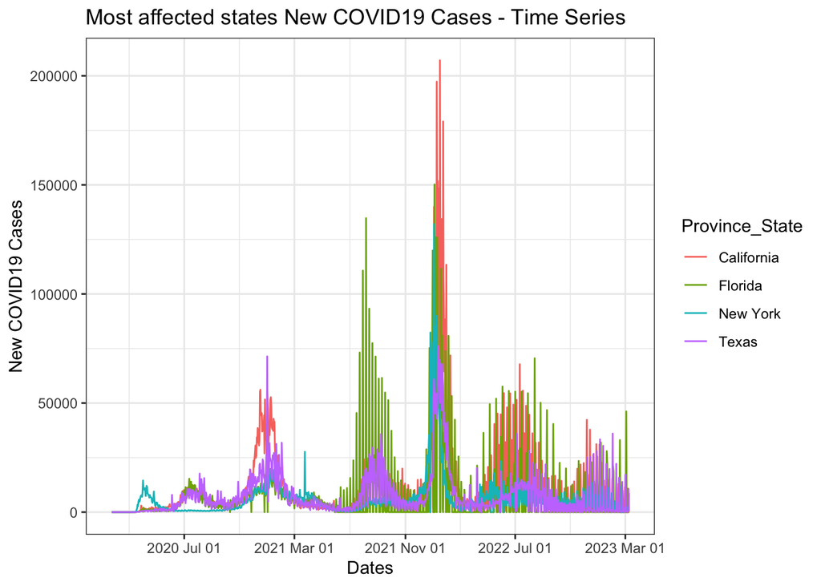

```r
# Create a new dataframe for Iron County and add columns for daily new cases and deaths.
top_total_cases <- states_detail_data %>%
  filter(Province_State %in% c("California", "Texas", "Florida", "New York"),
         new_cases >= 0,new_deaths >= 0)

ggplot(top_total_cases, aes(x=date)) +
  geom_line(aes(y = new_cases,color=Province_State)) +
  scale_x_date(date_labels = "%Y %b %d", date_breaks = "8 month") +
  theme_bw() +
  labs(x = "Dates",
       y = "New COVID19 Cases",
       title = "Most affected states New COVID19 Cases - Time Series")
```

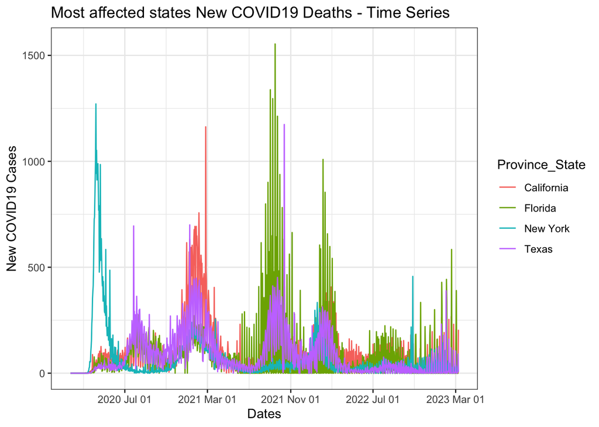

```r
ggplot(top_total_cases, aes(x=date)) +
  geom_line(aes(y = new_deaths,color=Province_State)) +
  scale_x_date(date_labels = "%Y %b %d", date_breaks = "8 month") +
  theme_bw() +
  labs(x = "Dates",
       y = "New COVID19 Cases",
       title = "Most affected states New COVID19 Deaths - Time Series")
```

### By cases_per_100, most affected states: Rhode Island, Alaska, Kentucky, North Dakota & Guam

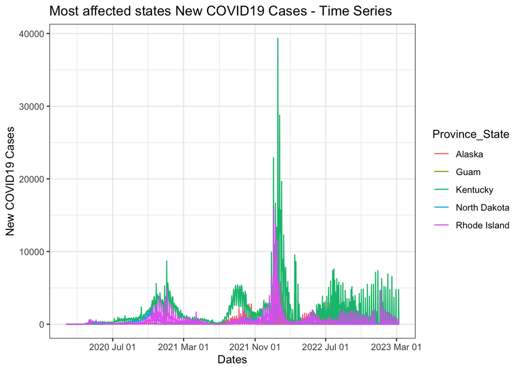

```r
# Create a new dataframe for Iron County and add columns for daily new cases and deaths.
top_states_cases <- states_detail_data %>%
  filter(Province_State %in% c("Rhode Island","Alaska","Kentucky","North Dakota","Guam"),
         new_cases >= 0,new_deaths >= 0)

ggplot(top_states_cases, aes(x=date)) +
  geom_line(aes(y = new_cases,color=Province_State)) +
  scale_x_date(date_labels = "%Y %b %d", date_breaks = "8 month") +
  theme_bw() +
  labs(x = "Dates",
       y = "New COVID19 Cases",
       title = "Most affected states New COVID19 Cases - Time Series")
```

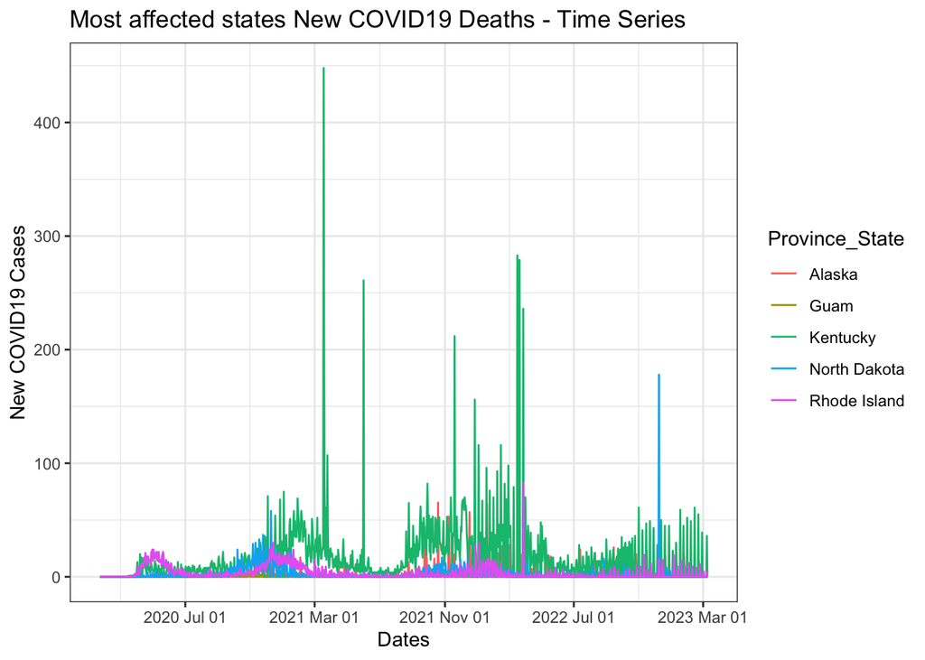

```r
ggplot(top_states_cases, aes(x=date)) +
  geom_line(aes(y = new_deaths,color=Province_State)) +
  scale_x_date(date_labels = "%Y %b %d", date_breaks = "8 month") +
  theme_bw() +
  labs(x = "Dates",
       y = "New COVID19 Cases",
       title = "Most affected states New COVID19 Deaths - Time Series")
```

### By deaths_per_100, most affected states: Arizona, Oklahoma, Mississippi, West Virginia & New Mexico

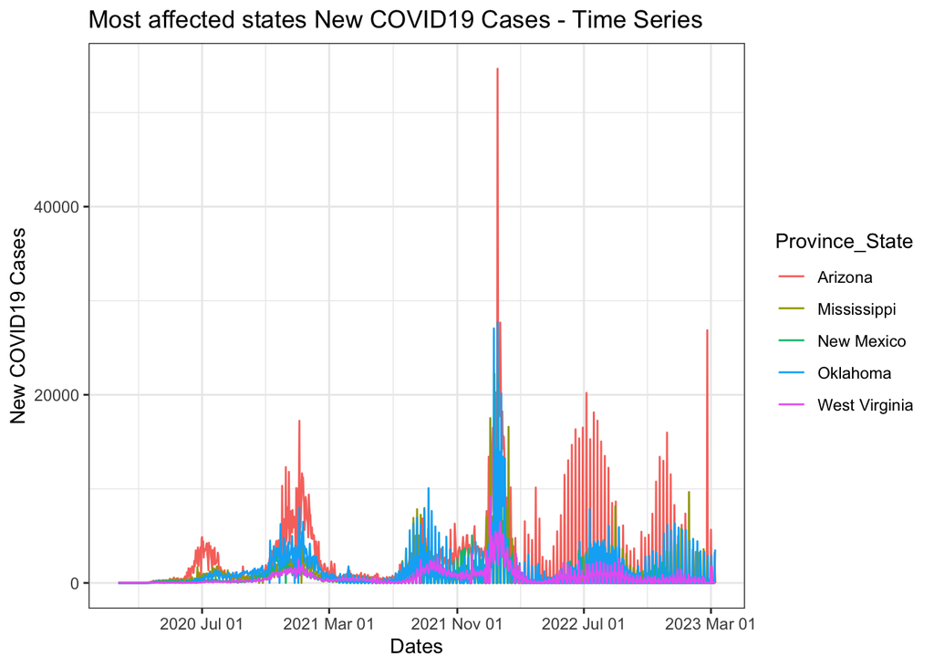

```r
# Create a new dataframe for Iron County and add columns for daily new cases and deaths.
top_states_deaths <- states_detail_data %>%
  filter(Province_State %in% c("Arizona", "Oklahoma", "Mississippi", "West Virginia","New Mexico"),
         new_cases >=0, new_deaths >= 0)

ggplot(top_states_deaths, aes(x=date)) +
  geom_line(aes(y = new_cases,color=Province_State)) +
  scale_x_date(date_labels = "%Y %b %d", date_breaks = "8 month") +
  theme_bw() +
  labs(x = "Dates",
       y = "New COVID19 Cases",
       title = "Most affected states New COVID19 Cases - Time Series")
```

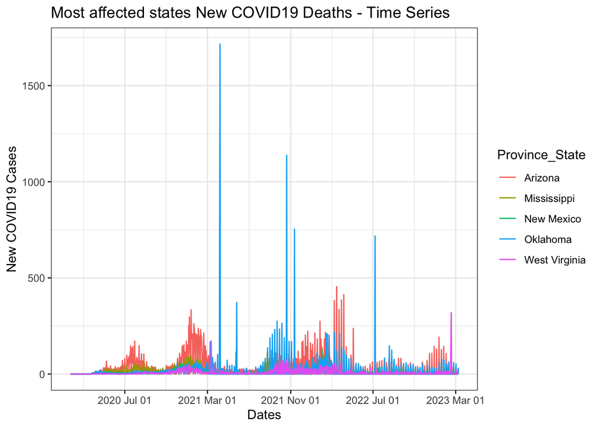

```r
ggplot(top_states_deaths, aes(x=date)) +
  geom_line(aes(y = new_deaths,color=Province_State)) +
  scale_x_date(date_labels = "%Y %b %d", date_breaks = "8 month") +
  theme_bw() +
  labs(x = "Dates",
       y = "New COVID19 Cases",
       title = "Most affected states New COVID19 Deaths - Time Series")
```

## Regression Model

```r
# Build the linear regression model.
lr_model <- lm(deaths_per_100 ~ cases_per_100, data = states_total)

# Display summmary for model analysis.
summary(lr_model)
```

```
##
## Call:
## lm(formula = deaths_per_100 ~ cases_per_100, data = states_total)
##
## Residuals:
##      Min       1Q   Median       3Q      Max
## -0.22690 -0.05992  0.01527  0.06138  0.12153
##
## Coefficients:
##                Estimate Std. Error t value Pr(>|t|)
## (Intercept)   -0.014972   0.045856  -0.327    0.745
## cases_per_100  0.010656   0.001494   7.132 2.09e-09 ***
## ---
## Signif. codes:  0 '***' 0.001 '**' 0.01 '*' 0.05 '.' 0.1 ' ' 1
##
## Residual standard error: 0.08471 on 56 degrees of freedom
## Multiple R-squared:  0.476,  Adjusted R-squared:  0.4666
## F-statistic: 50.86 on 1 and 56 DF,  p-value: 2.095e-09
```

**Model Observations**

- Coefficients:

coefficients represent the effect of the predictor variables on the response variable. The summary of coefficients is:

Intercept: -0.014972 (Estimate), 0.045856 (Std. Error), -0.327 (t value), 0.745 (Pr(>|t|)) cases_per_100: 0.010656 (Estimate), 0.001494 (Std. Error), 7.132 (t value), 2.09e-09 (Pr(>|t|)) The significance codes indicate that **cases_per_100** is highly significant (denoted by `***`).

- R-Squared:

Multiple R-squared: 0.476

Adjusted R-squared: 0.4666

These values indicate the proportion of the variance in the dependent variable that is predictable from the independent variable. An R-squared value of 0.476 implies that approximately 47.6% of the variability in **deaths_per_100** can be explained by the **cases_per_100**.

- F-Statistic

The F-statistic is 50.86, computed on 1 and 56 degrees of freedom, with a p-value of 2.095e-09. This statistic tests whether the overall regression model is a good fit for the data. The very small p-value indicates that the model is highly significant.

- In conclusion, the linear regression model shows a strong and significant correlation between the number of deaths per 100 and the number of cases per 100, with the predictor variable **cases_per_100** having a significant positive effect on the response variable **deaths_per_100**.

## Bias Identification

The analysis conducted in this report is not without bias as every source of data is biased in some way. When looking at any results from this report we should consider that each state is different in many ways, including population and health policy, and so the COVID-19 virus affected each state different.

## Conclusion

In terms of total cases and deaths, the most affected states were California, Texas, Florida & New York. However when checked by cases_per_100, it seems the most affected states were Rhode Island, Alaska, Kentucky, North Dakota & Guam. Whereas when checked by deaths_per_100, it seems the most affected states were Arizona, Oklahoma, Mississippi, West Virginia & New Mexico.

Also, the linear regression model shows a strong and significant correlation between the number of deaths per 100 and the number of cases per 100, with the predictor variable **cases_per_100** having a significant positive effect on the response variable **deaths_per_100**

In conclusion, this project has been an informative exploration for Covid-19 data for US. Further analysis can be done on Global Covid-19 data, to further extend these observations. Also, additional fields can also be combined in the model to further improve the model and prediction accuracy.